# Maps: Exercises

## Exercises

These exercises accompany the [Maps](http://rpubs.com/NateByers/maps) tutorial.

Use the following code to download 2014 daily No<sub>2</sub> data for the United States. This data will be used in the excercises.

```r
# create a temporary file
temp <- tempfile()

# download the .zip file to a temporary file--this might take a minute or two
download.file('http://aqsdr1.epa.gov/aqsweb/aqstmp/airdata/daily_42602_2014.zip', temp)

# unzip temporary file to your working directory
unzip(temp)

# delete the temporary file
unlink(temp)

# read the data into R
no2 <- read.csv('daily_42602_2014.csv', stringsAsFactors = FALSE)
```

1. Use `dplyr` to summarize the `no2` data frame so that each monitor has one record with a column for the NO<sub>2</sub> mean for the entire year and a column for the standard deviation.

Solution

2. Use the data frame created in the first exercise to create a map of the monitors (use `map()` and `points()`).

Solution

3. Use the data frame created in the first exercise and subset it down to monitors in Ohio. Plot those monitors on a map and label them with the “City.Name” column.

Solution

4. Use `choroplethr` to make a heat map of the number of NO<sub>2</sub> monitors in each state.

Solution

5. Use `googleVis` to make a Google map of the Ohio monitors.

Solution

6. Use `leaflet` to make a Leaflet map of the Ohio monitors.

Solution

## Solutions

### Solution 1

```r
library(dplyr)
as.tbl(no2)
```

```
## Source: local data frame [147,524 x 29]
##
##    State.Code County.Code Site.Num Parameter.Code   POC Latitude Longitude
##         (int)       (int)    (int)          (int) (int)    (dbl)     (dbl)
## 1           1          73       23          42602     1 33.55306   -86.815
## 2           1          73       23          42602     1 33.55306   -86.815
## 3           1          73       23          42602     1 33.55306   -86.815
## 4           1          73       23          42602     1 33.55306   -86.815
## 5           1          73       23          42602     1 33.55306   -86.815
## 6           1          73       23          42602     1 33.55306   -86.815
## 7           1          73       23          42602     1 33.55306   -86.815
## 8           1          73       23          42602     1 33.55306   -86.815
## 9           1          73       23          42602     1 33.55306   -86.815
## 10          1          73       23          42602     1 33.55306   -86.815
## ..        ...         ...      ...            ...   ...      ...       ...
## Variables not shown: Datum (chr), Parameter.Name (chr), Sample.Duration
##   (chr), Pollutant.Standard (chr), Date.Local (chr), Units.of.Measure
##   (chr), Event.Type (chr), Observation.Count (int), Observation.Percent
##   (dbl), Arithmetic.Mean (dbl), X1st.Max.Value (dbl), X1st.Max.Hour (int),
##   AQI (int), Method.Code (int), Method.Name (chr), Local.Site.Name (chr),
##   Address (chr), State.Name (chr), County.Name (chr), City.Name (chr),
##   CBSA.Name (chr), Date.of.Last.Change (chr)
```

```r
# filter out days with less than 75% valid hours
no2 <- filter(no2, Observation.Percent >= 75)
no2_annual <- group_by(no2, State.Code, County.Code, Site.Num,
                    Latitude, Longitude, Datum, State.Name,
                    County.Name, City.Name, CBSA.Name)
no2_annual <- summarize(no2_annual, no2_mean = mean(Arithmetic.Mean, na.rm = TRUE),
                        no2_sd = sd(Arithmetic.Mean, na.rm = TRUE))
as.tbl(no2_annual)
```

```
## Source: local data frame [447 x 12]
## Groups: State.Code, County.Code, Site.Num, Latitude, Longitude, Datum, State.Name, County.Name, City.Name [?]
##
##    State.Code County.Code Site.Num Latitude  Longitude Datum State.Name
##         (int)       (int)    (int)    (dbl)      (dbl) (chr)      (chr)
## 1           1          73       23 33.55306  -86.81500 WGS84    Alabama
## 2           1          73     2059 33.52143  -86.84411 NAD83    Alabama
## 3           2          90       34 64.84569 -147.72741 NAD83     Alaska
## 4           4          12     8000 34.23190 -113.58000 WGS84    Arizona
## 5           4          13       19 33.48385 -112.14257 WGS84    Arizona
## 6           4          13     3002 33.45793 -112.04601 WGS84    Arizona
## 7           4          13     3010 33.46093 -112.11748 WGS84    Arizona
## 8           4          13     4011 33.37005 -112.62070 WGS84    Arizona
## 9           4          13     4019 33.39625 -111.96797 NAD83    Arizona
## 10          4          13     9997 33.50383 -112.09577 WGS84    Arizona
## ..        ...         ...      ...      ...        ...   ...        ...
## Variables not shown: County.Name (chr), City.Name (chr), CBSA.Name (chr),
##   no2_mean (dbl), no2_sd (dbl)
```

Back to exercises

### Solution 2

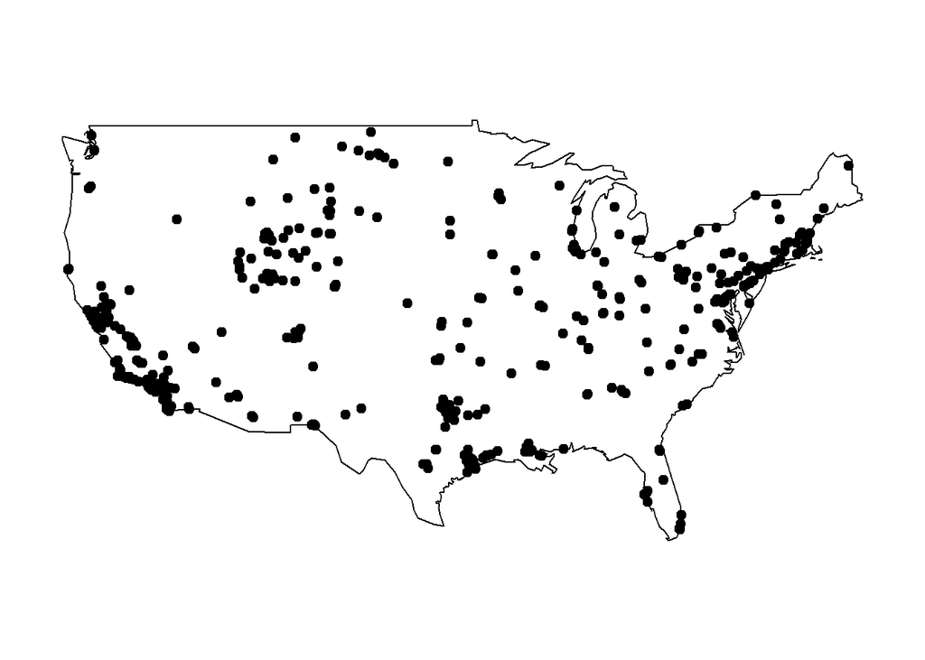

```r
library(maps)
map(database = 'usa')
points(x = no2_annual$Longitude, y = no2_annual$Latitude,pch = 19)
```

Back to exercises

### Solution 3

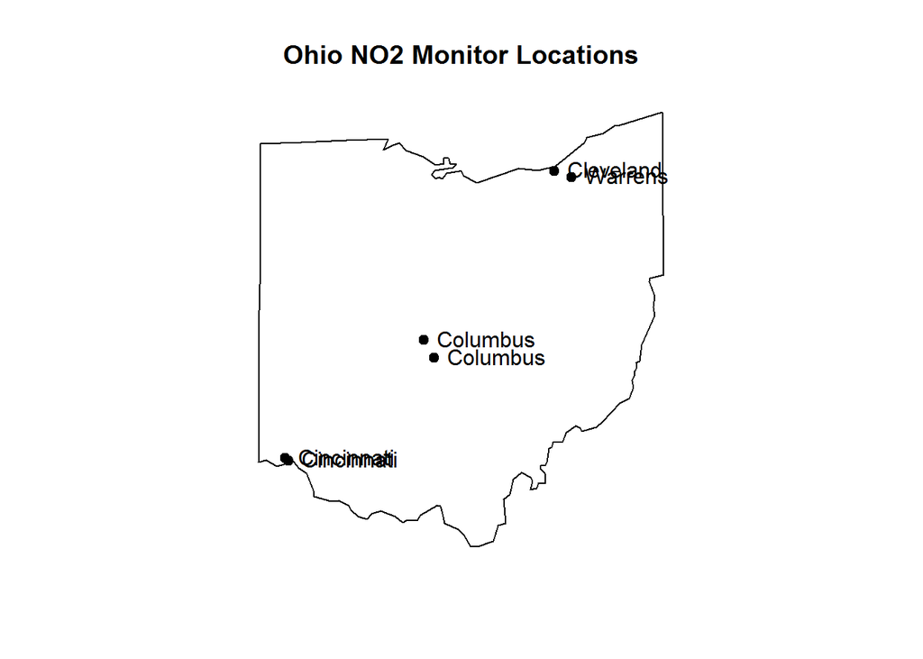

```r
ohio <- filter(no2_annual, State.Name == "Ohio")
map(database = 'state', regions = "ohio")
points(x = ohio$Longitude, y = ohio$Latitude,pch = 19)
title(main = "Ohio NO2 Monitor Locations")
text(x = ohio$Longitude, y = ohio$Latitude, labels = ohio$City.Name, pos = 4)
```

Back to exercises

### Solution 4

Make a summary table of the number of NO<sub>2</sub> monitors in each state.

```r
monitors <- group_by(no2_annual, State.Name)
monitors <- summarize(monitors, value = n())
```

Make a column named “region” that is all lowercase state names and has a `character` class. Remove non-states.

```r
monitors$region <- as.character(tolower(monitors$State.Name))
monitors <- filter(monitors, region != "puerto rico")
```

Plot.

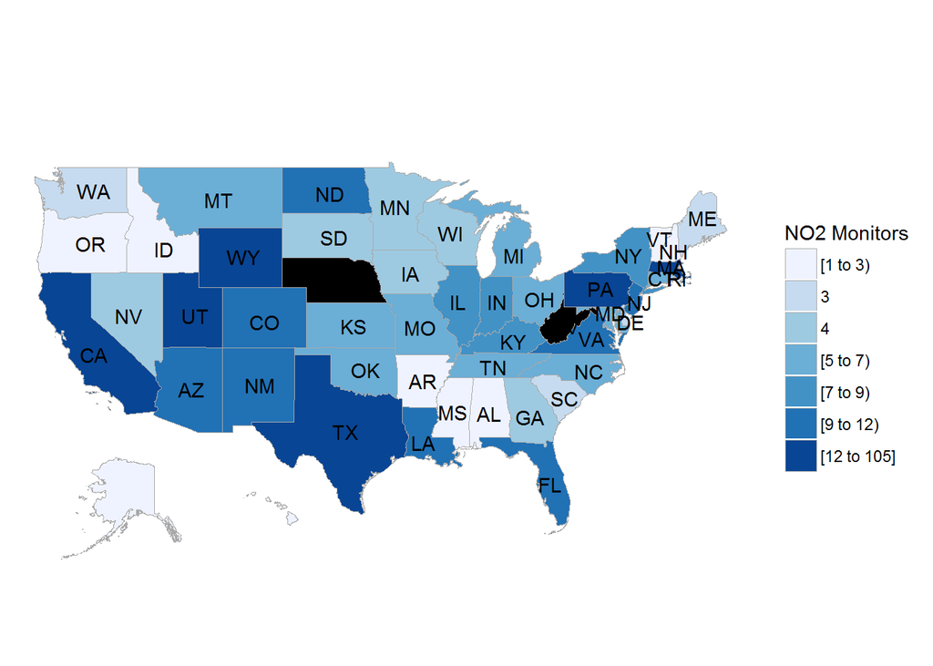

```r
library(choroplethr)
no2_map <- state_choropleth(monitors[, c("region", "value")],
                                  legend = "NO2 Monitors")
no2_map
```

Back to exercises

### Solution 5

```r
library(googleVis)
```

```r
ohio$google.location <- paste(ohio$Latitude, ohio$Longitude, sep = ":")
# here I create a more informative label
ohio$label <- paste("NO2 Annual Mean:", round(ohio$no2_mean, 3))
g.inter.map <- gvisMap(data = ohio, locationvar = "google.location",
                       tipvar = "label")
plot(g.inter.map)
```

Back to exercises

### Solution 6

```r
library(leaflet)
m <- leaflet()
m <- addTiles(m)
m <- addMarkers(m, lng=ohio$Longitude, lat=ohio$Latitude,
                popup=ohio$label)
m
```

[interactive chart not shown]

Back to exercises